# IMT2118 - Taller 2.

## 1. Aspectos generales.

- Fecha de entrega: 10 de septiembre 2020, 23:59.
- Formato de entrega: carpeta comprimida (.zip) incluyendo Jupyter Notebook con el desarrollo (puede utilizar este mismo notebook), y las capas o archivos vectoriales que haya generado como parte de su análisis. El objetivo es que **el Notebook pueda correr completamente dentro de la carpeta entregada**.
- Vía de entrega: a través de Canvas, correo electrónico con archivo adjunto o link para descarga (enviar a la profesora cc. al ayudante del curso).
- El trabajo es invididual, y cada estudiante trabajará con una región de Chile, de acuerdo a lo asignado para la Tarea 1 e indicado en la siguiente tabla:

| Estudiante | Región |
| --- | --- |
| Vicente Agüero | V |
| Matías Alarcón | VI |
| Pablo Bahamondes | VII |
| Beatriz Cuervo | VIII |
| Trindad Gatica | IX |
| David Quiroz | X |
| Josefa Silva | XI |
| Daniel Ugalde | XIII |
| Gerardo Ureta | XIV |
| Tomás Valenzuela | XVI |

- El Taller debe ser desarrollada en lenguaje de programación Python. Com parte de su trabajo, puede utilizar QGIS según le acomode para visualizar capas o realizar alguna operación espacial, pero para efectos de la entrega todo debe estar desarrollado en Python.
- Se sugiere hacer consultas y comentarios sobre el Taller a traves del Foro del curso creado en Google Groups.

## 2. Datos para el Taller.

Para el desarrollo de este Taller, utilizaremos los mismos conjuntos de datos requeridos para el desarrollo de la Tarea 1. El objetivo de esta actividad es preparar un subconjunto de datos correspondiente a la región asignada a cada estudiante, de manera de facilitar el resto del trabajo.

#### 2.1 Cartografía Censo 2017

http://www.censo2017.cl/resultados-precenso-2016/#1483043043443-4db741fa-4733

La cartografía censal incluye varias capas de utilidad para este análisis, como por ejemplo:

1. REGION_C17: límites regionales
2. COMUNA_C17: límites comunales
3. MANZANA_IND_C17: manzanas en zonas urbanas
4. MANZANA_ALDEA_C17: manzanas en zonas rurales
5. ENTIDAD_C17: entidares rurales
6. LIMITE_URBANO_CENSAL_C17: límite de las zonas urbanas (dentro de la cual se encuentran las manzanas urbanas).

#### 2.2 Red de hidrográfica de Chile.

Link: https://drive.google.com/file/d/1mHJI-pjI24-Ce45D5YVVt93nbcCox6ii/view?usp=sharing

Capa con todos los ríos, vertientes, lagos y otras fuentes de agua en Chile.

#### 2.3 Sistemas de Agua Potable Rural (APR).

Link: https://dga.mop.gob.cl/estudiospublicaciones/mapoteca/Paginas/default.aspx#cinco

Ubicación de los sistemas de APR administrados por el MOP. Para efectos de este análisis, asumiremos que la información está actualizada, y que estos son los únicos APR existentes, aunque en realidad existen algunos otros financiados por SUBDERE (pero la información georreferenciada no está disponible).

*Nota:* estas suposiciones revelan algunas de las falencias comúnmente encontradas en cuanto a disponibilidad de datos espaciales a nivel público y privado.

#### 2.4 Territorios operacionales de empresas sanitarias.

Link: https://drive.google.com/file/d/1mHJI-pjI24-Ce45D5YVVt93nbcCox6ii/view?usp=sharing

Zonas concesionada a empresas sanitarias de acuerdo a información publicada por la Superintendencia de Servicios Sanitarios (SISS). Corresponde al territorio cubierto por redes públicas de agua potable.

## 4. Desarrollo.

1. A partir de las conjuntos de datos indicados arriba, genere un nuevo conjunto de capas acotados únicamente a la región con la cual le corresponde trabajar, todas en sistema de coordenadas UTM.
2. Genere una figura donde se superpongan todas las capas generadas. Ud. puede definir las propiedades de visualización de cada capa, y no se evaluarán criterios gráficos en la medida que el mapa general de capas superpuestas sea comprensible.
3. A partir de su nuevo conjunto de datos, realice los cálculos necesarios para completar la siguiente tabla:

| Campo | Valor |
| --- | --- |
| Área total (Ha) | 1539625.6686917464 |
| Área total de zonas urbanas (Ha) | 83845.949733251 |
| Área total de entidades rurales (Ha) | 1429642.874566 |
| Población urbana | 6823859 |
| Población rural | 263441 |

```python
import numpy as np
import pandas as pd
import geopandas as gpd
import matplotlib.pyplot as plt
from shapely.geometry import Polygon, Point
import pyproj
```

```python
print(gpd.__version__)
```

```
0.8.1
```

```python
print(pyproj.__version__)
```

```
2.6.1.post1
```

```python
#función para transformar CRS SIRGAS - WGS84 UTM 19 sur
def cambiocrs(archivo,crt):
    gdf = gpd.read_file(archivo + '.shp')
    with open(archivo + '.prj') as prj_file:
        crs = prj_file.read()
    gdf.crs = crs
    gdf2 = gdf.to_crs(crt)
    return gdf2
```

```python
#No funciona
cambiocrs('R13/REGION_C17', 'EPSG:32719').crs
```

[output not shown]

```python
#Carga de datos
#Censo 2017
rm=gpd.read_file('R13/region_utm.shp')
comuna=gpd.read_file('R13/comuna_utm.shp')
rural=gpd.read_file('R13/manzana_aldea_utm.shp')
urbana=gpd.read_file('R13/manzana_ind_utm.shp')
entrural=gpd.read_file('R13/entidad_utm.shp')
lu=gpd.read_file('R13/lu_utm.shp')
#Otros
hidro=gpd.read_file('hidrografiaChile.gpkg')
apr=gpd.read_file('APR_DOH_Enero_2016/APR_DOH_Enero_2016.shp')
potable=gpd.read_file('territoriosOperacionalesSanitarias.gpkg')
```

```python
rm.crs
```

```
<Projected CRS: EPSG:32719>
Name: WGS 84 / UTM zone 19S
Axis Info [cartesian]:
- E[east]: Easting (metre)
- N[north]: Northing (metre)
Area of Use:
- name: World - S hemisphere - 72°W to 66°W - by country
- bounds: (-72.0, -80.0, -66.0, 0.0)
Coordinate Operation:
- name: UTM zone 19S
- method: Transverse Mercator
Datum: World Geodetic System 1984
- Ellipsoid: WGS 84
- Prime Meridian: Greenwich
```

```python
apr.crs
```

```
<Projected CRS: EPSG:32719>
Name: WGS 84 / UTM zone 19S
Axis Info [cartesian]:
- E[east]: Easting (metre)
- N[north]: Northing (metre)
Area of Use:
- name: World - S hemisphere - 72°W to 66°W - by country
- bounds: (-72.0, -80.0, -66.0, 0.0)
Coordinate Operation:
- name: UTM zone 19S
- method: Transverse Mercator
Datum: World Geodetic System 1984
- Ellipsoid: WGS 84
- Prime Meridian: Greenwich
```

```python
potable.crs
```

```
<Projected CRS: EPSG:32719>
Name: WGS 84 / UTM zone 19S
Axis Info [cartesian]:
- E[east]: Easting (metre)
- N[north]: Northing (metre)
Area of Use:
- name: World - S hemisphere - 72°W to 66°W - by country
- bounds: (-72.0, -80.0, -66.0, 0.0)
Coordinate Operation:
- name: UTM zone 19S
- method: Transverse Mercator
Datum: World Geodetic System 1984
- Ellipsoid: WGS 84
- Prime Meridian: Greenwich
```

```python
hidro.crs
```

```
<Projected CRS: EPSG:32719>
Name: WGS 84 / UTM zone 19S
Axis Info [cartesian]:
- E[east]: Easting (metre)
- N[north]: Northing (metre)
Area of Use:
- name: World - S hemisphere - 72°W to 66°W - by country
- bounds: (-72.0, -80.0, -66.0, 0.0)
Coordinate Operation:
- name: UTM zone 19S
- method: Transverse Mercator
Datum: World Geodetic System 1984
- Ellipsoid: WGS 84
- Prime Meridian: Greenwich
```

```python
len(hidro)
```

```
128367
```

```python
str(rm['geometry'][0]) #coordenadas UTM
```

```
'POLYGON ((337992.7389889684 6355760.045120709, 338145.4134332892 6355646.33209027, 338145.6210068945 6355646.17745398, 338265.2580007475 6355605.561867367, 338404.7054062131 6355599.012673305, 338416.2171452717 6355600.055473754, 338523.9556417706 6355609.814021564, 338554.8445089447 6355615.075666…
```

```python
hidro.plot()
```

[output not shown]

```python
potable.plot()
```

[output not shown]

```python
apr.plot()
```

[output not shown]

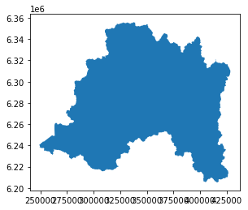

```python
rm.plot()
```

```python
apr.within(rm)
```

```
0       False
1       False
2       False
3       False
4       False
        ...
1776    False
1777    False
1778    False
1779    False
1780    False
Length: 1781, dtype: bool
```

```
118
```

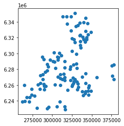

```python
apr_rm=gpd.overlay(apr,rm, how='intersection')
apr_rm.plot()
len(apr_rm)
```

```
3942
```

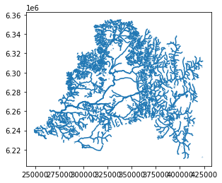

```python
hidro_rm=gpd.overlay(hidro,rm, how='intersection')
hidro_rm.plot()
len(hidro_rm)
```

```
56
```

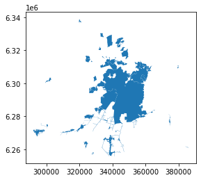

```python
potable_rm=gpd.overlay(potable, rm, how='intersection')
potable_rm.plot()
len(potable_rm)
```

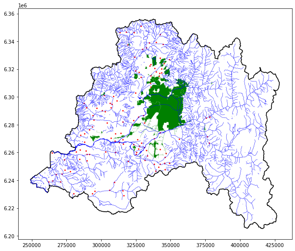

```python
fig=plt.figure(figsize=(10,10))
ax=fig.add_subplot(111)

ax.set_aspect('equal')
apr_rm.plot(ax=ax, color='r', markersize=3)
hidro_rm.plot(ax=ax, color='b', edgecolor='b', lw=0.5)
potable_rm.plot(ax=ax, color='g')
rm.plot(ax=ax, color='none', edgecolor='k', lw=1.5)

plt.show()
```

```python
#Exportación de datos
#formato Shapefile (ESRI)
apr_rm.to_file('productos/shp/apr_RM.shp')
hidro_rm.to_file('productos/shp/hidro_RM.shp')
potable_rm.to_file('productos/shp/potable_RM.shp')
rm.to_file('productos/shp/RM.shp')

#formato GeoJSON
apr_rm.to_file('productos/geojson/apr_RM.geojson', driver='GeoJSON')
hidro_rm.to_file('productos/geojson/hidro_RM.geojson', driver='GeoJSON')
potable_rm.to_file('productos/geojson/potable_RM.geojson', driver='GeoJSON')
rm.to_file('productos/geojson/RM.geojson', driver='GeoJSON')

#formato GeoPackage
apr_rm.to_file("productos/gpkg/package.gpkg", layer='apr', driver="GPKG")
hidro_rm.to_file("productos/gpkg/package.gpkg", layer='hidro', driver="GPKG")
potable_rm.to_file("productos/gpkg/package.gpkg", layer='potable', driver="GPKG")
rm.to_file("productos/gpkg/package.gpkg", layer='rm', driver="GPKG")
```

```python
area_rm=rm.area.sum()*0.0001
```

```python
print('El área de la Región Metropolitana es:', area_rm, 'Ha')
```

```
El área de la Región Metropolitana es: 1539625.6686917464 Ha
```

```python
area_urbana=urbana.area.sum()*0.0001
```

```python
print('El área urbana de la Región Metropolitana es:', area_urbana, 'Ha')
```

```
El área urbana de la Región Metropolitana es: 83845.949733251 Ha
```

```python
area_entrural=entrural.area.sum()*0.0001
```

```python
print('El área de las entidades rurales de la Región Metropolitana es:', area_entrural, 'Ha')
```

```
El área de las entidades rurales de la Región Metropolitana es: 1429642.8745655464 Ha
```

```python
pob_urb=urbana['TOTAL_PERS']
```

```python
print('La población urbana de la Región Metropolitana es:', sum(pob_urb), 'habitantes')
```

```
La población urbana de la Región Metropolitana es: 6823859 habitantes
```

```python
pob_rural=entrural['TOTAL_PERS']
```

```python
print('La población rural de la Región Metropolitana es:', sum(pob_rural), 'habitantes')
```

```
La población rural de la Región Metropolitana es: 263441 habitantes
```

```python
#NO funciono
mask=apr.geometry.squeeze().within(rm)
print(mask.sum(),len(apr))

apr_rm2=apr[mask]
```

```
0 1781
```

```python
type(apr.geometry.squeeze())
```

```
geopandas.geoseries.GeoSeries
```